# Projet Data Camp: Cinema

Master 2 Miage 2021-2022

Alexis Sidate - Gabriel Jestin

## Population

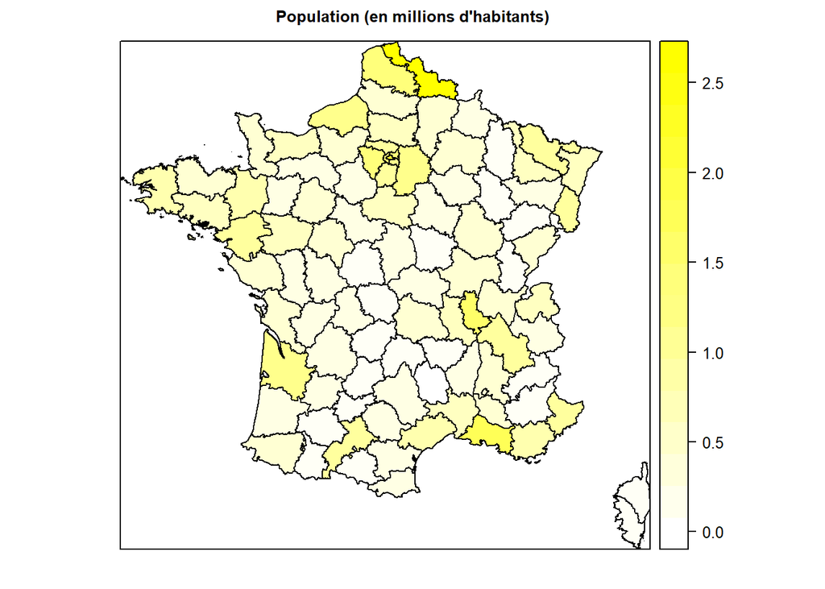

## Nombre de cinémas

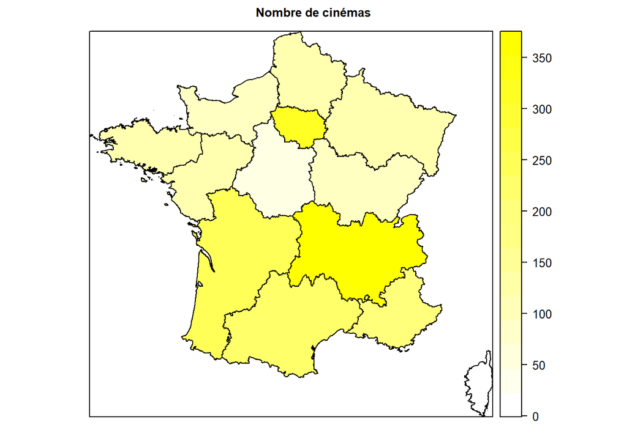

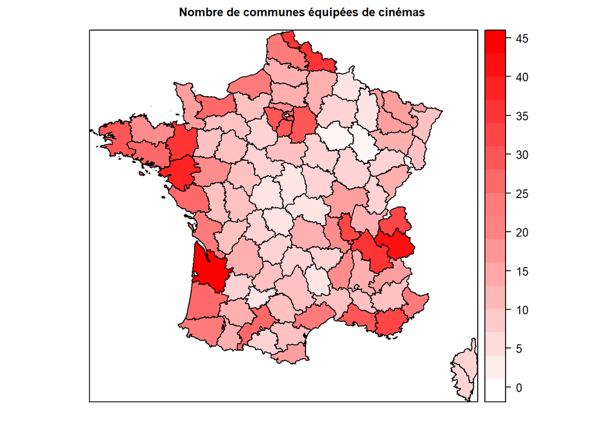

La carte ci-dessus à gauche montre le nombre de cinémas par région, on peut voir qu’il y a plus de cinémas en Ile-De-France et dans la moitié Sud de le France. La carte de droite montre que ce ne sont pas forcément ces zones géographiques qui ont le plus de villes équipées de cinémas (le nord et le nord-ouest notamment), on peut donc deviner qu’il y a un grand nombre de cinémas situés dans les mêmes villes (notamment les grandes villes évoquées précédemment).

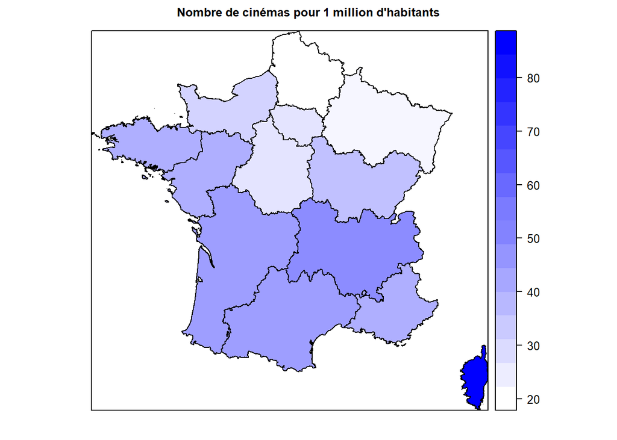

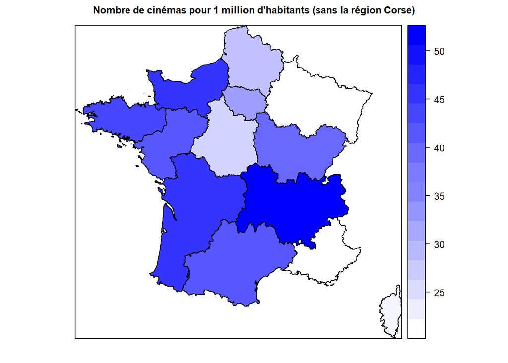

## Les entrées

```
## Total des entrées en France en 2002 : 184,459,000 .
```

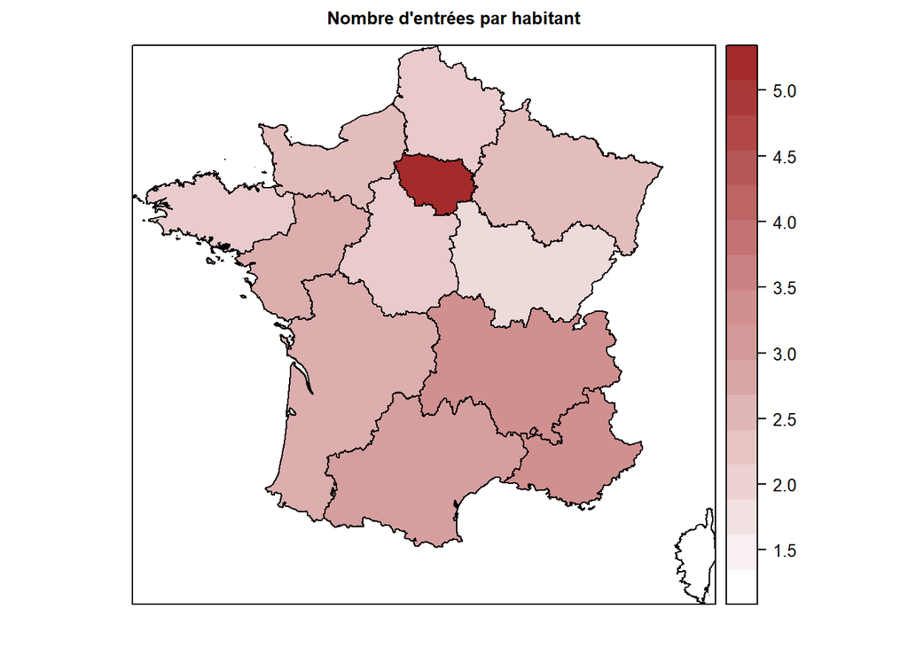

Ci-dessus, on observe que les franciliens se rendent plus au cinema que dans les autres régions (plus de 5 fois par habitant en moyenne°.

On peut voir ci-dessous une très forte domination au niveau des entrées par la région Ile-De-France qui peut facilement s’expliquer par la très forte population présente à Paris et en banlieue parisienne ou encore grâce au tourisme très élevé par rapport aux autres villes françaises.

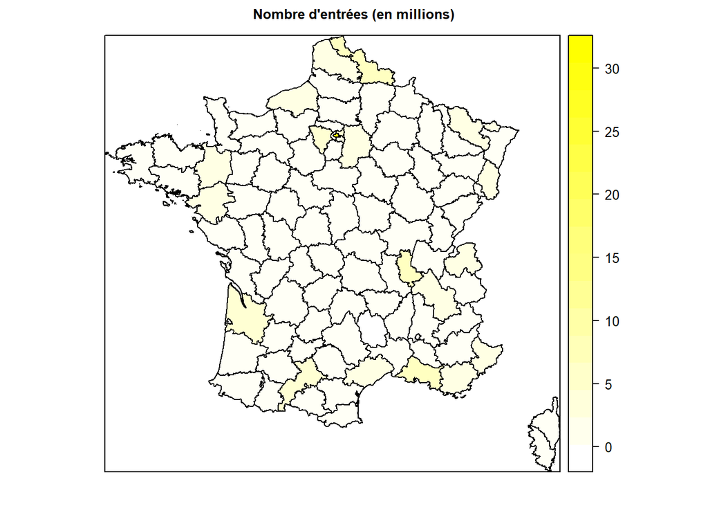

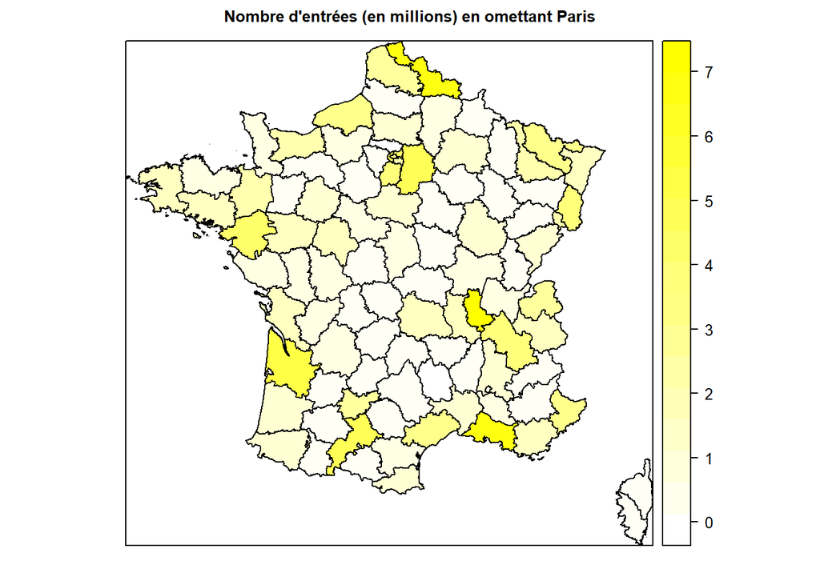

Cette différence est encore plus visible lorsque compare le nombre d’entrées par département en incluant Paris ou non (voir cartes ci-dessus).

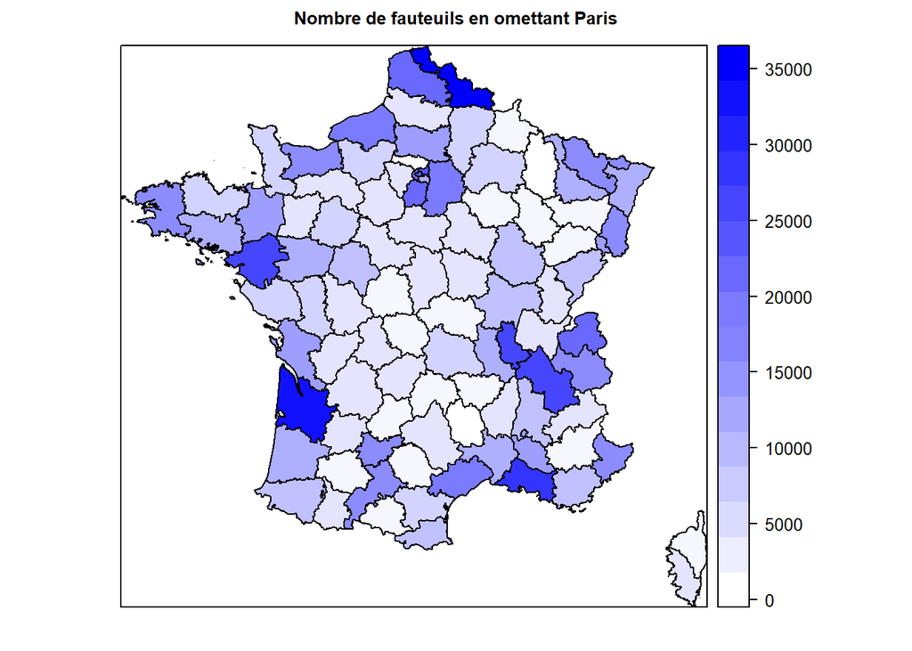

La carte ci-dessus du nombre de fauteuils est très similaire à la carte du nombre d’entrées, cependant elle diffère de la carte du nombre de communes équipées, on peut notamment voir la différence au niveau de la Bretagne, ceci peut s’expliquer par la densité de population moins élevée que dans d’autres régions, obligeant peut-être un plus grand nombre de villes à s’équiper de cinémas de plus petites tailles.

## Les recettes

```
## Total des recettes en France : €1,027,869,000 .
```

Les 5 régions les plus rentables

| Region | Recettes |
| --- | --- |
| Île-de-France | €332,885,000 |
| Auvergne-Rhône-Alpes | €124,711,000 |
| Provence-Alpes-Côte d’Azur | €90,640,000 |
| Grand Est | €80,320,000 |
| Occitanie | €74,578,000 |

Directement lié au nombre d’entrées par habitant, le total des recettes est donc naturellement le plus élevée dans la région Ile-De-France. Ci-dessous, le graphique de gauche met en évidence la part très conséquente des recettes qui sont faites en Île-De-France par rapport au reste du pays, à droite on observe que les recettes sont proportionnelles au nombre d’habitant, mais quand sont même beaucoup plus élevées Île-De-France.

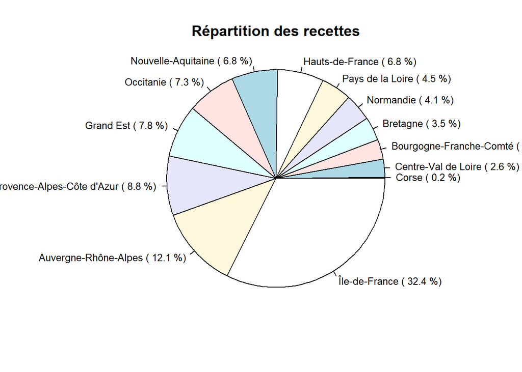

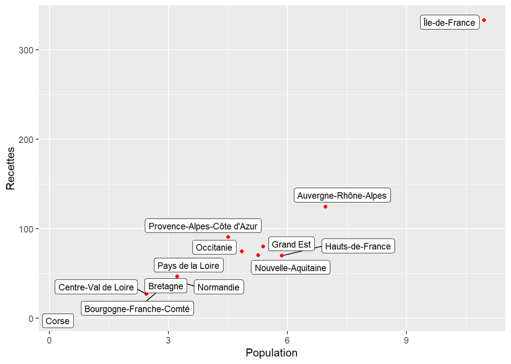